# Job Board Effectiveness for College Students

Author

Affiliation

Yasmeen R’ghioui

George Washington University

Published

March 22, 2026

## Overview

How effective are job boards at helping college students land jobs, and do they actually work at all? These are the central questions driving this analysis. Using a dataset sourced from Kaggle, last updated March 18th, 2026, and refreshed annually, I will explore how three major platforms — Handshake, LinkedIn, and Indeed — perform for entry-level job seekers.

The dataset contains 100,000 student records spanning demographics like major, university tier, and region, alongside academic indicators such as GPA and prior internship experience. It tracks the full application funnel from submissions to first and second round interviews, all the way to offers received. For students who secured an offer, additional details like salary, company size, and role relevance are included.

Through a series of data visualizations, this analysis examines which platforms, majors, and student backgrounds are most associated with successful job outcomes and what the data reveals about the modern college job search.

```python
import numpy as np
import pandas as pd
import matplotlib.pyplot as plt
import seaborn as sns
import plotly.express as px
from sklearn.datasets import load_iris
import calendar
data = pd.read_csv("job_data.csv")
```

```python
#data cleaning
data['University_Rating'] = pd.Categorical(
    data['University_Rating'],
    categories=['Lower-tier', 'Mid-tier', 'Top-tier'],
    ordered=True
)

#data sorting
data.sort_values(['GPA', 'Offer_Salary'], ascending=[False, False], na_position='last').head(3)

#groupby
platform_stats = (
    data.groupby('Primary_Search_Platform', observed=True)
    .agg(
        offer_rate = ('Offer_Received',        'mean'),
        avg_apps   = ('Applications_Submitted', 'mean'),
        med_salary = ('Offer_Salary',           'median')
    )
    .round(2)
)

#reshaping
data_long = data[['Student_ID', 'Primary_Search_Platform',
              'Applications_Submitted', 'First_Round_Interviews', 'Second_Round_Interviews']
            ].melt(
    id_vars   = ['Student_ID', 'Primary_Search_Platform'],
    var_name  = 'Funnel_Stage',
    value_name= 'Count'
)
```

### Offer Rate Based On Job Platform

This bar chart presents job offer rates by job platform. We can observe that Handshake and LinkedIn are tied with 37% of students who used each platform receiving a job offer. Indeed was ranked the lowest at just 26% of students receiving job offers.

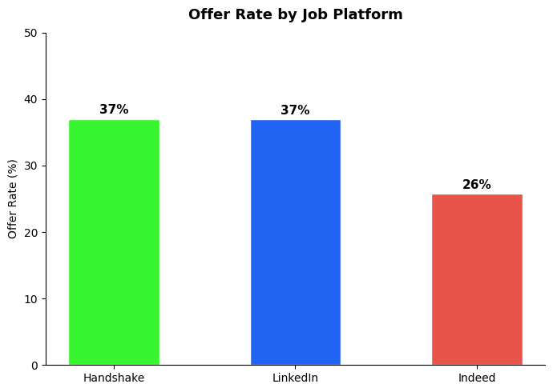

```python
platform_stats2 = (
    data.groupby('Primary_Search_Platform', observed=True)['Offer_Received']
    .mean()
    .reset_index()
    .sort_values('Offer_Received', ascending=False)
)

colors = ['#38f52f', '#2164f3', '#e8534a']

fig, ax = plt.subplots(figsize=(7, 5))

bars = ax.bar(
    platform_stats2['Primary_Search_Platform'],
    platform_stats2['Offer_Received'] * 100,
    color=colors,
    width=0.5,
    edgecolor='white'
)

for bar, val in zip(bars, platform_stats2['Offer_Received']):
    ax.text(bar.get_x() + bar.get_width()/2, bar.get_height() + 0.4,
            f'{val:.0%}', ha='center', va='bottom', fontsize=11, fontweight='bold')

ax.set_title('Offer Rate by Job Platform', fontsize=13, fontweight='bold', pad=12)
ax.set_ylabel('Offer Rate (%)', fontsize=10)
ax.set_ylim(0, 50)
ax.spines[['top', 'right']].set_visible(False)
ax.tick_params(axis='x', labelsize=10)

plt.tight_layout()
plt.savefig('offer_rate_barplot.png', dpi=150, bbox_inches='tight')
plt.show()
```

### Percentages of Students Who Received Offers vs. Students Who Didn’t

This donut chart shows that out of 100,000 students, 34,229 (34.2%) received an offer, and 65,771 (65.8%) did not.

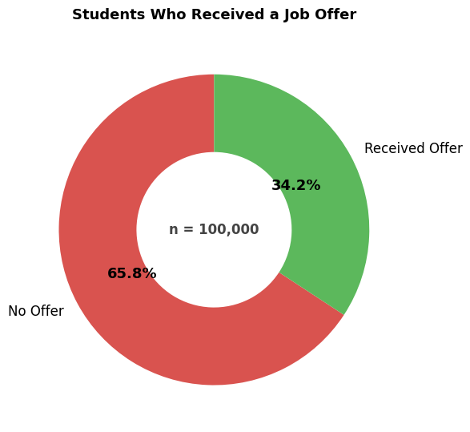

```python
counts = data['Offer_Received'].value_counts().sort_index()
labels = ['No Offer', 'Received Offer']
colors = ['#d9534f', '#5cb85c']

fig, ax = plt.subplots(figsize=(6, 6))

wedges, texts, autotexts = ax.pie(
    counts,
    labels=labels,
    colors=colors,
    autopct='%1.1f%%',
    startangle=90,
    wedgeprops=dict(width=0.5),
    textprops=dict(fontsize=12)
)

for at in autotexts:
    at.set_fontsize(13)
    at.set_fontweight('bold')

ax.text(0, 0, f'n = {len(data):,}', ha='center', va='center',
        fontsize=12, fontweight='bold', color='#444')

ax.set_title('Students Who Received a Job Offer', fontsize=13,
             fontweight='bold', pad=15)

plt.tight_layout()
plt.savefig('offer_donut.png', dpi=150, bbox_inches='tight')
plt.show()
```

### Offer Rate Based On Major and University Tier

This slope chart shows how offer rates shift from Lower-tier to Top-tier across every major simultaneously. We can observe that business students receive the highest offer rates regardless of major and university tier, while healthcare students receive the lowest at lower-tier universities, and arts students receive the lowest at mid-tier and top-tier universities.

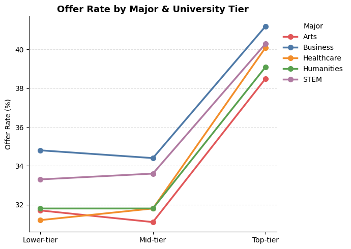

```python
data['University_Rating'] = pd.Categorical(
    data['University_Rating'],
    categories=['Lower-tier', 'Mid-tier', 'Top-tier'], ordered=True
)

slope_data = (
    data.groupby(['Major_Category', 'University_Rating'], observed=True)['Offer_Received']
    .mean()
    .round(3)
    .reset_index()
)

majors = sorted(slope_data['Major_Category'].unique())
tiers  = ['Lower-tier', 'Mid-tier', 'Top-tier']
colors = ['#e15759', '#4e79a7', '#f28e2b', '#59a14f', '#b07aa1']

fig, ax = plt.subplots(figsize=(7, 5))

for i, major in enumerate(majors):
    subset = slope_data[slope_data['Major_Category'] == major].sort_values('University_Rating')
    ax.plot(tiers, subset['Offer_Received'] * 100, color=colors[i],
            linewidth=2.5, marker='o', markersize=7, label=major)

ax.set_title('Offer Rate by Major & University Tier', fontsize=13, fontweight='bold')
ax.set_ylabel('Offer Rate (%)')
ax.spines[['top', 'right']].set_visible(False)
ax.legend(title='Major', bbox_to_anchor=(1, 1), loc='upper left', frameon=False)
ax.grid(axis='y', linestyle='--', alpha=0.4)

plt.tight_layout()
plt.savefig('slope_chart.png', dpi=150, bbox_inches='tight')
plt.show()
```

### Offer Salary Distribution Based On Major

This boxplot shows salary spread by major based on medians, ranges, and outliers all at once. It is sorted low to high by median, so the gap is immediately obvious. STEM sits nearly $20k above Arts/Humanities/Healthcare at the median, and also has the widest spread, meaning high upside but more variance in what you’ll actually land.

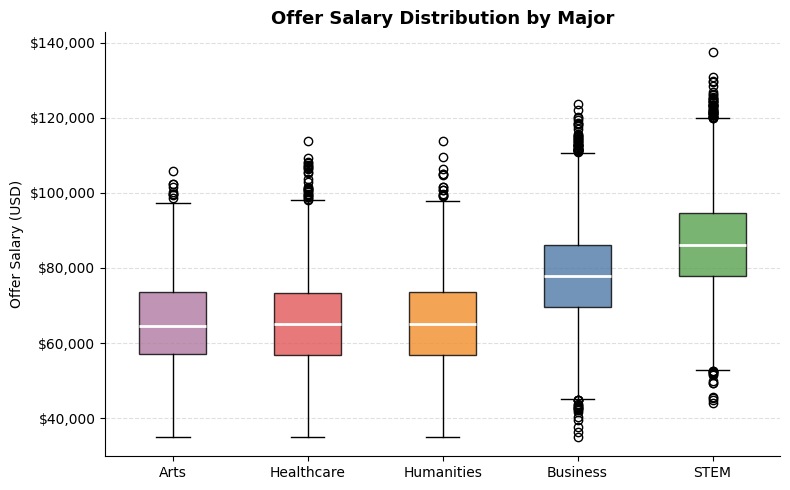

```python
offers = data[data['Offer_Received'] == 1]
order  = offers.groupby('Major_Category')['Offer_Salary'].median().sort_values().index

data2   = [offers[offers['Major_Category'] == m]['Offer_Salary'].values for m in order]
colors = ['#b07aa1', '#e15759', '#f28e2b', '#4e79a7', '#59a14f']

fig, ax = plt.subplots(figsize=(8, 5))

bp = ax.boxplot(data2, patch_artist=True, notch=False,
                medianprops=dict(color='white', linewidth=2))

for patch, color in zip(bp['boxes'], colors):
    patch.set_facecolor(color)
    patch.set_alpha(0.8)

ax.set_xticklabels(order, fontsize=10)
ax.set_title('Offer Salary Distribution by Major', fontsize=13, fontweight='bold')
ax.set_ylabel('Offer Salary (USD)')
ax.yaxis.set_major_formatter(plt.FuncFormatter(lambda x, _: f'${x:,.0f}'))
ax.spines[['top', 'right']].set_visible(False)
ax.grid(axis='y', linestyle='--', alpha=0.4)

plt.tight_layout()
plt.savefig('salary_boxplot.png', dpi=150, bbox_inches='tight')
plt.show()
```

### Offer Rate Based On Number of Prior Internships

This is a line plot that shows how the offer rate changes as the number of prior internships increases. Each point on the line represents the average offer rate for students with that many internships, making it easy to see whether having more internship experience leads to a higher chance of receiving a job offer.

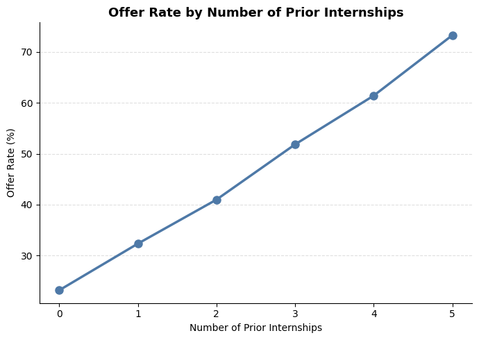

```python
internship_offer = (
    data.groupby('Prior_Internships')['Offer_Received']
    .mean()
    .reset_index()
)

fig, ax = plt.subplots(figsize=(7, 5))

ax.plot(internship_offer['Prior_Internships'],
        internship_offer['Offer_Received'] * 100,
        color='#4e79a7', linewidth=2.5, marker='o', markersize=8)

ax.set_title('Offer Rate by Number of Prior Internships', fontsize=13, fontweight='bold')
ax.set_xlabel('Number of Prior Internships')
ax.set_ylabel('Offer Rate (%)')
ax.set_xticks(internship_offer['Prior_Internships'])
ax.spines[['top', 'right']].set_visible(False)
ax.grid(axis='y', linestyle='--', alpha=0.4)

plt.tight_layout()
plt.savefig('internship_line.png', dpi=150, bbox_inches='tight')
plt.show()
```

### Offer Rate Across GPA Range

This is a bar chart that shows the offer rate for students across four GPA ranges: Below 2.5, 2.5–3.0, 3.0–3.5, and 3.5–4.0. Each bar represents the percentage of students in that GPA range who received a job offer, making it easy to see whether academic performance plays a role in job search success.

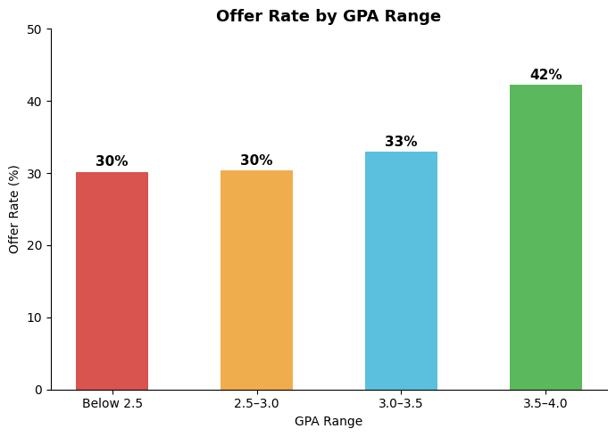

```python
# Bin GPA into ranges
data['GPA_Bin'] = pd.cut(data['GPA'], bins=[0, 2.5, 3.0, 3.5, 4.0],
                        labels=['Below 2.5', '2.5–3.0', '3.0–3.5', '3.5–4.0'])

offer_by_gpa = (
    data.groupby('GPA_Bin', observed=True)['Offer_Received']
    .mean()
    .reset_index()
)

fig, ax = plt.subplots(figsize=(7, 5))

bars = ax.bar(offer_by_gpa['GPA_Bin'], offer_by_gpa['Offer_Received'] * 100,
              color=['#d9534f', '#f0ad4e', '#5bc0de', '#5cb85c'], width=0.5)

for bar, val in zip(bars, offer_by_gpa['Offer_Received']):
    ax.text(bar.get_x() + bar.get_width()/2, bar.get_height() + 0.4,
            f'{val:.0%}', ha='center', va='bottom', fontsize=11, fontweight='bold')

ax.set_title('Offer Rate by GPA Range', fontsize=13, fontweight='bold')
ax.set_xlabel('GPA Range')
ax.set_ylabel('Offer Rate (%)')
ax.set_ylim(0, 50)
ax.spines[['top', 'right']].set_visible(False)

plt.tight_layout()
plt.savefig('gpa_offer_rate.png', dpi=150, bbox_inches='tight')
plt.show()
```

## Final Reflection

This analysis explored job search outcomes among 100,000 college students using data from three major platforms: LinkedIn, Handshake, and Indeed. Across all visualizations, several patterns emerged that reveal both the opportunities and limitations students face in today’s job market.